# Williams-Celeste-Homework-03

C. Williams

3/19/2019

## PROBLEM 1

```r
Z.prop.test <- function(p1,n1,p2,n2,alt,CL) {
  pstar<-(p1+p2)/(n1+n2)
  phat1<- p1/ n1
  phat2<- p2/n2
  pi<-0
  Z<-(phat2 - phat1)/ sqrt((pstar * (1-pstar))*((1/n1)+ (1/n2)))
  n1 * pi >5
  n2 * pi>5
  n1*(1-pi)> 5
  n2*(1-pi)>5
  p.upper<-1-pnorm(Z, lower.tail=TRUE)
  p.lower<- pnorm(Z,lower.tail = FALSE)
  p<- p.upper + p.lower
  pt <- prop.test(x = c(p2,p1), n = c(n2,n1), alternative = alt, conf.level = CL, correct=FALSE)
  pt
  results<-c(Z,p,pt$conf.int)
  return(results)
}
```

#### Example

```r
x<-c(1, 0, 1, 1, 0, 0, 1, 1, 0, 0, 1, 1, 1, 1, 0, 0, 1, 1, 0, 0, 1, 1, 0,
     1, 0)
y<-c(1, 1, 0, 0, 1, 1, 1, 1, 0, 1, 0, 1, 1, 1, 0, 1, 0, 1, 1, 1, 1, 1, 0,
     0, 1, 1, 0, 1, 1, 1)
p1<-sum(x)
n1<-length(x)
p2<- sum(y)
n2<- length(y)
alt<- "two.sided"
CL<-0.95
```

```r
Z.prop.test(p1,n1,p2,n2,alt,CL)
```

```
## [1]  1.0747093  0.2825049 -0.1144634  0.3944634
```

## PROBLEM 2

#### Fit the regression model and, using {ggplot2}, produce a scatterplot with the fitted line superimposed upon the data. Append the the fitted model equation to your plot.

```r
f<-"~/Desktop/KamilarandCooperData.csv"
d <- read_csv(f, col_names = TRUE)
head(d)
```

```
## # A tibble: 6 x 44
##   Scientific_Name Family Genus Species Brain_Size_Spec… Brain_Size_Fema…
##   <chr>           <chr>  <chr> <chr>              <dbl>            <dbl>
## 1 Allenopithecus… Cerco… Alle… nigrov…             58.0             53.7
## 2 Allocebus_tric… Cerco… Allo… tricho…             NA               NA
## 3 Alouatta_belze… Ateli… Alou… belzeb…             52.8             51.2
## 4 Alouatta_caraya Ateli… Alou… caraya              52.6             47.8
## 5 Alouatta_guari… Ateli… Alou… guariba             51.7             49.1
## 6 Alouatta_palli… Ateli… Alou… pallia…             49.9             48.0
## # … with 38 more variables: Brain_size_Ref <chr>,
## #   Body_mass_male_mean <dbl>, Body_mass_female_mean <dbl>,
## #   Mass_Dimorphism <dbl>, Mass_Ref <chr>, MeanGroupSize <dbl>,
## #   AdultMales <dbl>, AdultFemale <dbl>, AdultSexRatio <dbl>,
## #   Social_Organization_Ref <chr>, InterbirthInterval_d <dbl>,
## #   Gestation <dbl>, WeaningAge_d <dbl>, MaxLongevity_m <dbl>,
## #   LitterSz <dbl>, Life_History_Ref <chr>, GR_MidRangeLat_dd <dbl>,
## #   Precip_Mean_mm <dbl>, Temp_Mean_degC <dbl>, AET_Mean_mm <dbl>,
## #   PET_Mean_mm <dbl>, Climate_Ref <chr>, HomeRange_km2 <dbl>,
## #   HomeRangeRef <chr>, DayLength_km <dbl>, DayLengthRef <chr>,
## #   Territoriality <dbl>, Fruit <dbl>, Leaves <chr>, Fauna <chr>,
## #   DietRef1 <chr>, Canine_Dimorphism <dbl>, Canine_Dimorphism_Ref <chr>,
## #   Feed <dbl>, Move <dbl>, Rest <dbl>, Social <dbl>,
## #   Activity_Budget_Ref <chr>
```

```r
names(d)
```

```
##  [1] "Scientific_Name"         "Family"
##  [3] "Genus"                   "Species"
##  [5] "Brain_Size_Species_Mean" "Brain_Size_Female_Mean"
##  [7] "Brain_size_Ref"          "Body_mass_male_mean"
##  [9] "Body_mass_female_mean"   "Mass_Dimorphism"
## [11] "Mass_Ref"                "MeanGroupSize"
## [13] "AdultMales"              "AdultFemale"
## [15] "AdultSexRatio"           "Social_Organization_Ref"
## [17] "InterbirthInterval_d"    "Gestation"
## [19] "WeaningAge_d"            "MaxLongevity_m"
## [21] "LitterSz"                "Life_History_Ref"
## [23] "GR_MidRangeLat_dd"       "Precip_Mean_mm"
## [25] "Temp_Mean_degC"          "AET_Mean_mm"
## [27] "PET_Mean_mm"             "Climate_Ref"
## [29] "HomeRange_km2"           "HomeRangeRef"
## [31] "DayLength_km"            "DayLengthRef"
## [33] "Territoriality"          "Fruit"
## [35] "Leaves"                  "Fauna"
## [37] "DietRef1"                "Canine_Dimorphism"
## [39] "Canine_Dimorphism_Ref"   "Feed"
## [41] "Move"                    "Rest"
## [43] "Social"                  "Activity_Budget_Ref"
```

```r
d<- d[!(is.na(d$Brain_Size_Species_Mean)),]
d <- d[!(is.na(d$MaxLongevity_m)),]
head(d)
```

```
## # A tibble: 6 x 44
##   Scientific_Name Family Genus Species Brain_Size_Spec… Brain_Size_Fema…
##   <chr>           <chr>  <chr> <chr>              <dbl>            <dbl>
## 1 Allenopithecus… Cerco… Alle… nigrov…             58.0             53.7
## 2 Alouatta_caraya Ateli… Alou… caraya              52.6             47.8
## 3 Alouatta_palli… Ateli… Alou… pallia…             49.9             48.0
## 4 Alouatta_pigra  Ateli… Alou… pigra               51.1             48.8
## 5 Alouatta_senic… Ateli… Alou… senicu…             55.2             54.3
## 6 Aotus_azarai    Cebid… Aotus azarai              20.7             20.7
## # … with 38 more variables: Brain_size_Ref <chr>,
## #   Body_mass_male_mean <dbl>, Body_mass_female_mean <dbl>,
## #   Mass_Dimorphism <dbl>, Mass_Ref <chr>, MeanGroupSize <dbl>,
## #   AdultMales <dbl>, AdultFemale <dbl>, AdultSexRatio <dbl>,
## #   Social_Organization_Ref <chr>, InterbirthInterval_d <dbl>,
## #   Gestation <dbl>, WeaningAge_d <dbl>, MaxLongevity_m <dbl>,
## #   LitterSz <dbl>, Life_History_Ref <chr>, GR_MidRangeLat_dd <dbl>,
## #   Precip_Mean_mm <dbl>, Temp_Mean_degC <dbl>, AET_Mean_mm <dbl>,
## #   PET_Mean_mm <dbl>, Climate_Ref <chr>, HomeRange_km2 <dbl>,
## #   HomeRangeRef <chr>, DayLength_km <dbl>, DayLengthRef <chr>,
## #   Territoriality <dbl>, Fruit <dbl>, Leaves <chr>, Fauna <chr>,
## #   DietRef1 <chr>, Canine_Dimorphism <dbl>, Canine_Dimorphism_Ref <chr>,
## #   Feed <dbl>, Move <dbl>, Rest <dbl>, Social <dbl>,
## #   Activity_Budget_Ref <chr>
```

*longevity~brain size*

```r
BS<- d$Brain_Size_Species_Mean
ML<- d$MaxLongevity_m
beta1<- cor(ML,BS) * (sd(ML)/sd(BS))
beta1
```

```
## [1] 1.21799
```

```r
beta0<- mean(ML) - beta1 * mean(BS)
beta0
```

```
## [1] 248.9523
```

```r
a<-lm(MaxLongevity_m ~ Brain_Size_Species_Mean, data=d)
a
```

```
##
## Call:
## lm(formula = MaxLongevity_m ~ Brain_Size_Species_Mean, data = d)
##
## Coefficients:
##             (Intercept)  Brain_Size_Species_Mean
##                 248.952                    1.218
```

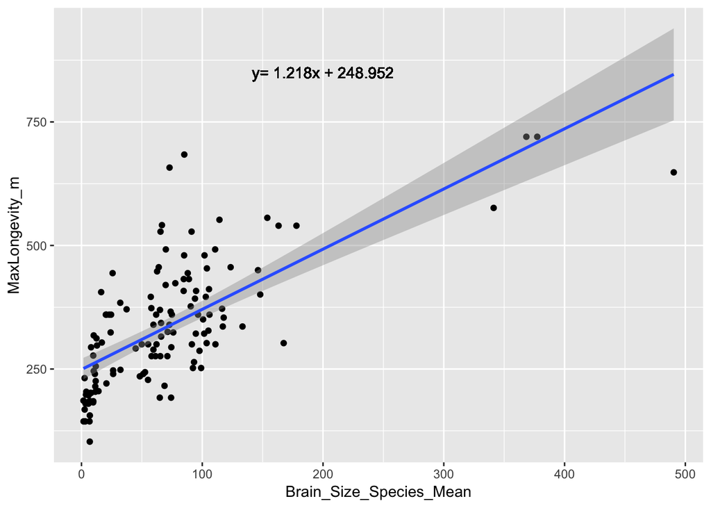

```r
plot1<- ggplot(data = d, aes(x=Brain_Size_Species_Mean, y=MaxLongevity_m, label="y= 1.218x + 248.952"))+ geom_point()+ geom_smooth(method = lm, formula = y~x)+ geom_text(x = 200, y = 850, label= "y= 1.218x + 248.952")
plot1
```

*log(longevity)~log(brain size)*

```r
log_BS<- log(d$Brain_Size_Species_Mean)
log_ML<- log(d$MaxLongevity_m)
beta1.2<- cor(log_BS,log_ML) * (sd(log_ML)/sd(log_BS))
beta1.2
```

```
## [1] 0.2341496
```

```r
beta0.2<- mean(log_ML) - (beta1.2 * mean(log_BS))
beta0.2
```

```
## [1] 4.878951
```

```r
b<-lm(log_ML ~ log_BS, data=d)
b
```

```
##
## Call:
## lm(formula = log_ML ~ log_BS, data = d)
##
## Coefficients:
## (Intercept)       log_BS
##      4.8790       0.2341
```

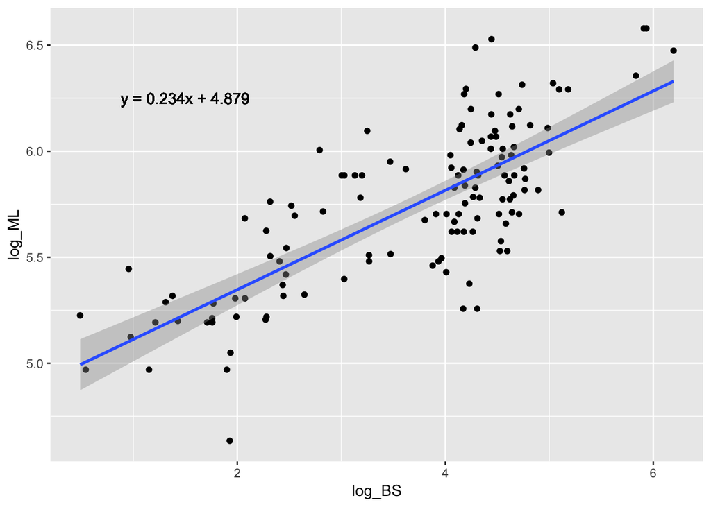

```r
plot2<-ggplot(data=d,aes(x=log_BS, y=log_ML))+ geom_point()+geom_smooth(method = lm, formula = y~x)+geom_text(x = 1.5, y = 6.25, label= "y = 0.234x + 4.879")
plot2
```

#### Identify and interpret the point estimate of the slope (β1), as well as the outcome of the test associated with the hypotheses H0: β1=0; HA: β1≠0. Also, find a 90% CI for the slope (β1) parameter.

*longevity~brain size*

```r
pe_beta1<- predict(a,newdata = data.frame(Brain_Size_Species_Mean=beta1), interval = "confidence", level=0.90)
pe_beta1
```

```
##        fit     lwr      upr
## 1 250.4358 232.177 268.6945
```

```r
beta1==0
```

```
## [1] FALSE
```

*log(longevity)~log(brain size)*

```r
pe2_beta1<- predict(b,newdata = data.frame(log_BS=beta1), interval = "confidence", level=0.90)
pe2_beta1
```

```
##        fit      lwr      upr
## 1 5.164143 5.082955 5.245331
```

```r
beta1==0
```

```
## [1] FALSE
```

#### Using your model, add lines for the 90% confidence and prediction interval bands on the plot, and add a legend to differentiate between the lines.

*longevity~brain size*

```r
ci <- predict(a, newdata = data.frame(Brain_Size_Species_Mean = d$Brain_Size_Species_Mean), interval = "confidence", level = 0.90)
head(ci)
```

```
##        fit      lwr      upr
## 1 319.6201 306.1354 333.1047
## 2 313.0551 299.3805 326.7297
## 3 309.7056 295.9081 323.5032
## 4 311.2281 297.4886 324.9676
## 5 316.2097 302.6349 329.7845
## 6 274.1281 258.0873 290.1690
```

```r
df1<- cbind(BS, ML, ci)
df1<- as.data.frame(df1)
head(df1)
```

```
##      BS    ML      fit      lwr      upr
## 1 58.02 276.0 319.6201 306.1354 333.1047
## 2 52.63 243.6 313.0551 299.3805 326.7297
## 3 49.88 300.0 309.7056 295.9081 323.5032
## 4 51.13 240.0 311.2281 297.4886 324.9676
## 5 55.22 300.0 316.2097 302.6349 329.7845
## 6 20.67 360.0 274.1281 258.0873 290.1690
```

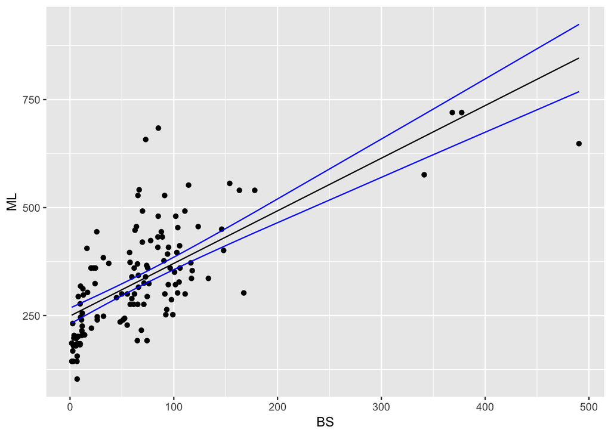

```r
plot1<-ggplot(data = df1, aes(x=BS, y=ML))+geom_point()+geom_line(aes(x=BS,y=fit),colour="black") + geom_line(aes(x=BS,y=lwr),colour="blue") + geom_line(aes(x=BS,y=upr), colour="blue")
plot1
```

```r
pi<-predict(a,newdata = data.frame(Brain_Size_Species_Mean = d$Brain_Size_Species_Mean), interval = "prediction", level = 0.90)
head(pi)
```

```
##        fit      lwr      upr
## 1 319.6201 168.3750 470.8651
## 2 313.0551 161.7930 464.3172
## 3 309.7056 158.4324 460.9789
## 4 311.2281 159.9601 462.4961
## 5 316.2097 164.9566 467.4628
## 6 274.1281 122.6338 425.6225
```

```r
df1<- cbind(df1,pi)
names(df1)<- c("BS", "ML","CIfit", "CIlwr", "CIupr", "PIfit", "PIlwr","PIupr")
head(df1)
```

```
##      BS    ML    CIfit    CIlwr    CIupr    PIfit    PIlwr    PIupr
## 1 58.02 276.0 319.6201 306.1354 333.1047 319.6201 168.3750 470.8651
## 2 52.63 243.6 313.0551 299.3805 326.7297 313.0551 161.7930 464.3172
## 3 49.88 300.0 309.7056 295.9081 323.5032 309.7056 158.4324 460.9789
## 4 51.13 240.0 311.2281 297.4886 324.9676 311.2281 159.9601 462.4961
## 5 55.22 300.0 316.2097 302.6349 329.7845 316.2097 164.9566 467.4628
## 6 20.67 360.0 274.1281 258.0873 290.1690 274.1281 122.6338 425.6225
```

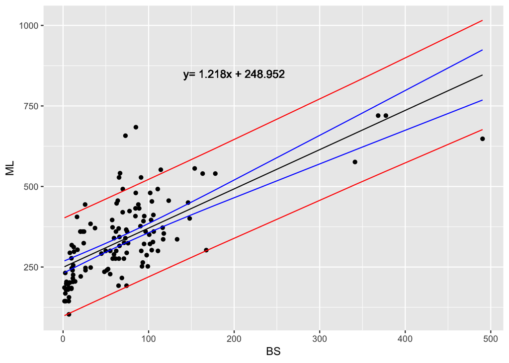

```r
plot1<- plot1 + geom_line(data = df1, aes(x=BS, y=PIlwr), colour="red") + geom_line(data=df1, aes(x=BS, y=PIupr), colour= "red")+ geom_text(x = 200, y = 850, label= "y= 1.218x + 248.952")
plot1
```

*log(longevity)~log(brain size)*

```r
ci2 <- predict(b, newdata = data.frame(logBrain_Size_Species_Mean = log_BS), interval = "confidence", level = 0.90)
head(ci2)
```

```
##        fit      lwr      upr
## 1 5.829783 5.791675 5.867891
## 2 5.806953 5.769598 5.844308
## 3 5.794387 5.757357 5.831416
## 4 5.800182 5.763011 5.837354
## 5 5.818201 5.780501 5.855901
## 6 5.588116 5.546999 5.629233
```

```r
df2<- cbind(log_BS, log_ML, ci2)
df2<- as.data.frame(df2)
head(df2)
```

```
##     log_BS   log_ML      fit      lwr      upr
## 1 4.060788 5.620401 5.829783 5.791675 5.867891
## 2 3.963286 5.495528 5.806953 5.769598 5.844308
## 3 3.909620 5.703782 5.794387 5.757357 5.831416
## 4 3.934371 5.480639 5.800182 5.763011 5.837354
## 5 4.011325 5.703782 5.818201 5.780501 5.855901
## 6 3.028683 5.886104 5.588116 5.546999 5.629233
```

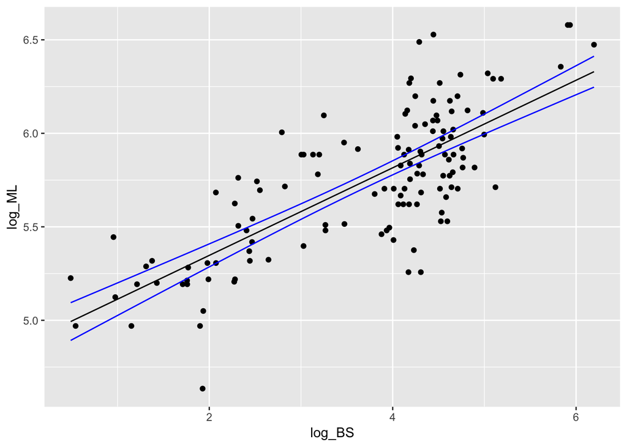

```r
plot2<-ggplot(data = df2, aes(x=log_BS, y=log_ML))+geom_point()+geom_line(aes(x=log_BS,y=fit),colour="black") + geom_line(aes(x=log_BS,y=lwr),colour="blue") + geom_line(aes(x=log_BS,y=upr), colour="blue")
plot2
```

```r
pi<-predict(b,newdata = data.frame(logBrain_Size_Species_Mean = log_BS), interval = "prediction", level = 0.90)
head(pi)
```

```
##        fit      lwr      upr
## 1 5.829783 5.416322 6.243243
## 2 5.806953 5.393561 6.220344
## 3 5.794387 5.381024 6.207749
## 4 5.800182 5.386807 6.213557
## 5 5.818201 5.404778 6.231624
## 6 5.588116 5.174367 6.001864
```

```r
df2<- cbind(df2,pi)
names(df2)<- c("log_BS", "log_ML","CIfit", "CIlwr", "CIupr", "PIfit", "PIlwr","PIupr")
head(df2)
```

```
##     log_BS   log_ML    CIfit    CIlwr    CIupr    PIfit    PIlwr    PIupr
## 1 4.060788 5.620401 5.829783 5.791675 5.867891 5.829783 5.416322 6.243243
## 2 3.963286 5.495528 5.806953 5.769598 5.844308 5.806953 5.393561 6.220344
## 3 3.909620 5.703782 5.794387 5.757357 5.831416 5.794387 5.381024 6.207749
## 4 3.934371 5.480639 5.800182 5.763011 5.837354 5.800182 5.386807 6.213557
## 5 4.011325 5.703782 5.818201 5.780501 5.855901 5.818201 5.404778 6.231624
## 6 3.028683 5.886104 5.588116 5.546999 5.629233 5.588116 5.174367 6.001864
```

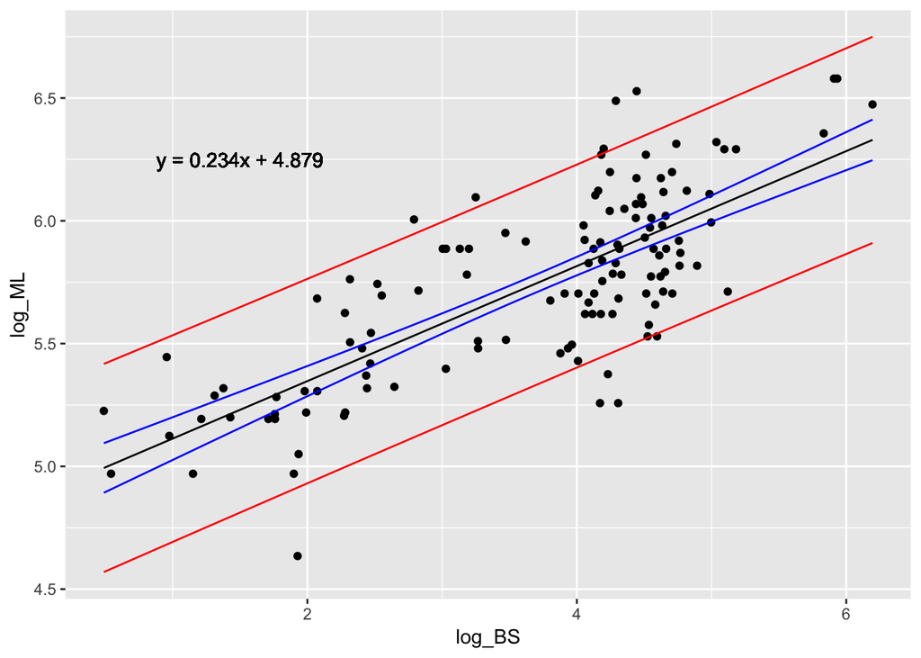

```r
plot2<- plot2 + geom_line(data = df2, aes(x=log_BS, y=PIlwr), colour="red") + geom_line(data=df2, aes(x=log_BS, y=PIupr), colour= "red")+geom_text(x = 1.5, y = 6.25, label= "y = 0.234x + 4.879")
plot2
```

#### Produce a point estimate and associated 90% prediction interval for the longevity of a species whose brain weight is 800 gm. Do you trust the model to predict observations accurately for this value of the explanatory variable? Why or why not?

*longevity~brain size*

```r
pi800<- predict(a,newdata = data.frame(Brain_Size_Species_Mean=800), interval = "prediction", level=0.90)
pi800
```

```
##        fit      lwr      upr
## 1 1223.345 1021.805 1424.884
```

##### No, because most of the brain sizes are under 200 grams. Our data/graph may not accurately depict the longevity of species when the brain size is over a certain weight, or until there is more data for species.

*log(longevity)~log(brain size)*

```r
pi2_800<- predict(b,newdata = data.frame(log_BS=log(800)), interval = "prediction", level=0.90)
pi2_800
```

```
##       fit      lwr      upr
## 1 6.44415 6.021424 6.866876
```

##### I trust this model to predict observations more accurately because there are at least a few values that we can see directly that are clode to our estimates, whereas for the previous model we had no x-value even near our estimate.

#### Looking at your two models, which do you think is better? Why?

##### When looking at the two models, I would say the log one is better because it is more evenly spread than model 1. Also, our point estimates showed that it may only be a good estimator for certain brain weights, whereas the log model at least had a couple of points near our estimator.